# STA141 final project

### 7. Visualize success rate change over time:

The success rate for each session is shown binned in 25-trial increments to help illustrate how outcomes can change over time. Success rates shown here have quite a bit of variation both across and within sessions, which reflects how dynamic the decision-making process might be. For some sessions, there is a clear pattern of increasing success rate which might reflect some slowly decreasing noise — that is, the process of learning or adaptation taking place. On other sessions, the success rate shows more of a variability. The specific trails might be mildly varying in difficulty, depending on the exact nature of the stimuli the mice receive. In other sessions, the variation might reflect mice themselves getting a bit shakier. A plot like this shows how events mimic a motion of updating an inner state, an ability to make correct decisions given a certain stimulus The binned nature of the success rate plots presents a slightly different view of trails, showing how often a particular etude looks good toward the end of a trial compared with how it looks at the midpoint.

The graphs below depict the rate of success for each session. It is plotted against the number of sessions completed, where we have 18 binned in 25 trials. For some sessions, there is a high initial rate of success that declines at a later stage. This might reflect an initial familiarity with the task that is then lost either due to fatigue or a reduced determination to try and complete the task. Some sessions tend to be much more stable in their performance and might reflect a degree of consistency in performance or that the task was matched to the level of ability of the mouse to perform the specific task.

Relative to the individual mice, Cori, Forssmann, Hench and Lederberg each have distinct patterns over time in terms of success rate: the line for Cori shows a decreasing slope, which would suggest a gradual diminishing in performance or even exhaustion with the trials; the line for Forssmann indicates a linear stability before it plummets in the last couple of trials; the pattern for Hench shows some fluctuations with considerable variance, which is suggestive of instability in performance or the difficulty of the task; Lederberg’s pattern has some mountain peaks and valleys, which is indicative of some conditions or times presenting more prone to the successful outcomes.

The success rate change over time for individual sessions:

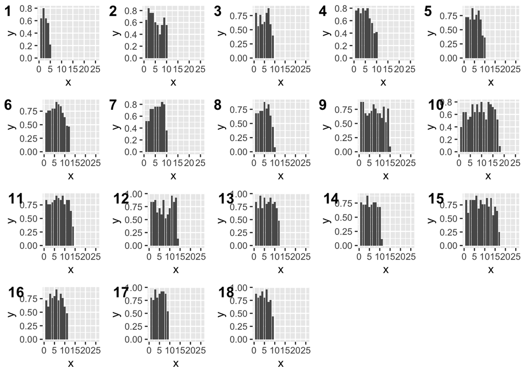

The success rate change over time for individual mouse:

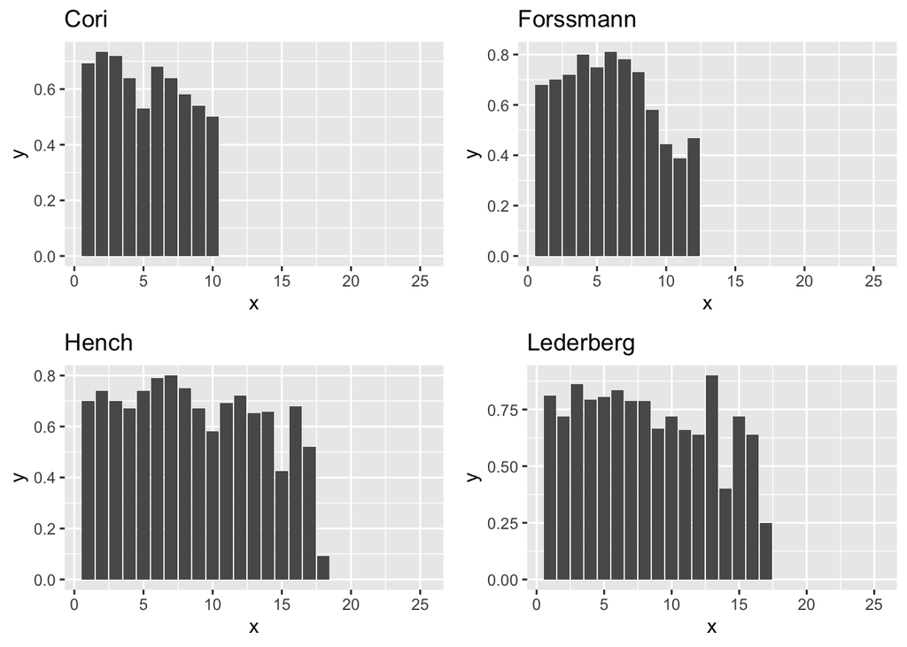

### 8. Dimension Reduction through PCA:

The dots are colored for different session.

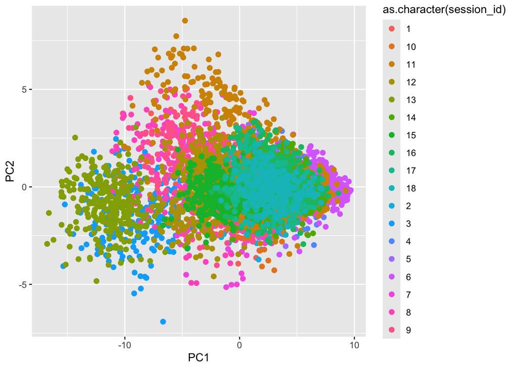

The dots are colored for different mouse

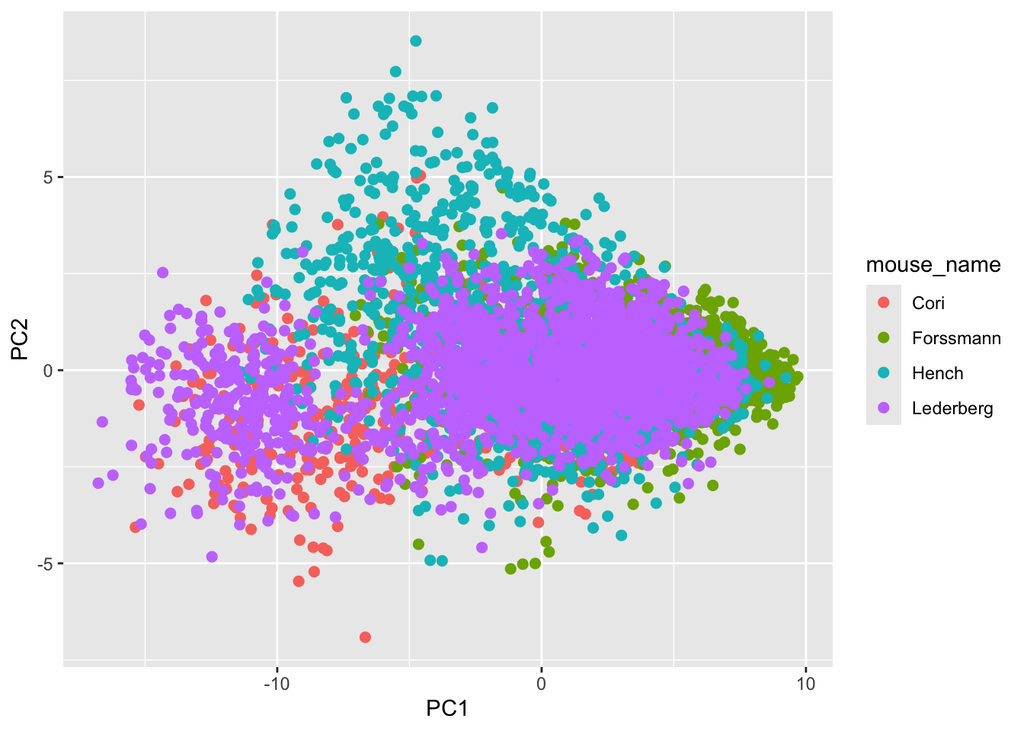

## II. Data Integration

Each row of the data set represents a specific trial, and within each trial are several variables representing the different things measured in that trial – the experimental data from each mouse.

These are variables named :session_id: A unique identifier of a session. It is a very important variable from a temporal point of view that will allow detecting the temporal relationships among the recorded events.trials_id: A unique identifier of the trials (left and right responses separate). A crude analysis on individual trials is possible. This feature is crucial for the detection and characterisation of trial-by-trial dynamics.contrast_left: The level of contrast for the stimulus in the left visual field during a trial. Contrast is one of the salient feature of the stimuli, therefore a major suspect for manipulating the mouse decision.contrast_right: The level of contrast for the stimulus in the right visual field during a trial. Another salient feature of the stimuli, again a major suspect for influencing the mouse decision.contrast_diff: The difference between contrast_left and contrast_right. It is an indicator of the difference in the relative strength of the stimuli shown to the animal, and can be directly related to the decision process in the trials.mean_trail_spike: The mean number of spikes recorded from the neuron during a trial. The most relevant response variable in the trials.PC1 and PC2: The first two principal components obtained from the PCA plotted in the space of these features. These features are likely the neuron spike-counts in a few seconds time-bins.

These terms are dimensionality reductions of the input data that retain the most variance, and are used to reduce dimensionality (from grey matter size, blood volume and connectivity, to three values: age, gender, depression, etc, etc.) while retaining as much information as possible. The column “feedback labels” is a mapping from feedback type to binary outcomes (successes or failures) of each trial, where the original feedback types of 1 for ‘success’ and -1 for ‘failure’ has been transformed, with -1 mapped to 0 due to how binary classification algorithms are constructed.

```
##   session_id trail_id contrast_left contrast_right contrast_diff
## 1          1        1           0.0            0.5           0.5
## 2          1        2           0.0            0.0           0.0
## 3          1        3           0.5            1.0           0.5
## 4          1        4           0.0            0.0           0.0
## 5          1        5           0.0            0.0           0.0
## 6          1        6           0.0            0.0           0.0
##   mean_trail_spike        PC1        PC2
## 1         1.581744 -2.2588258  2.1940797
## 2         1.311989  0.5751501  0.5974122
## 3         1.844687 -4.9516212  0.3259103
## 4         1.381471 -0.1216140 -3.9415449
## 5         1.425068 -0.5461632 -1.1757684
## 6         1.094005  2.9055458  0.7481911
```